# Data Visualization Project Prentation: Ford bike sharing dataset

## Insight 1:

Even though almost an equal number of bikes are rented during mornings and afternoons, when this data is narrowed down to only the ten most popular stations, it is found that the number of rentals during the mornings are far more than the number of rentals during the afternoons. This indicate that in other stations, most bikes are rented during afternoons.

See the graphs below which illustarate the above statement

### Distribution by Period of Day Trend of bike rides at all stations

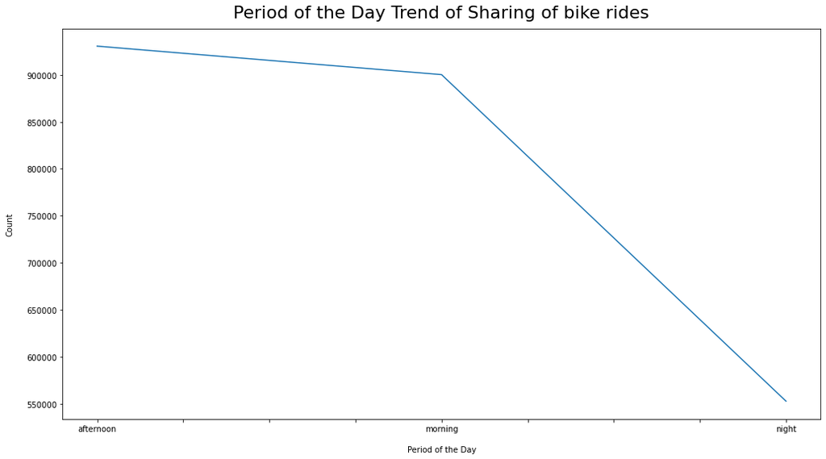

```python
df.groupby('period_of_day').agg({'bike_id':'count'}).plot(style='-', legend=False, figsize=(17,9))
plt.title('Period of the Day Trend of Sharing of bike rides', fontsize=22, y=1.015)
plt.xlabel('Period of the Day', labelpad=16)
plt.ylabel('Count', labelpad=16);
```

### Distribution by Period of Day Trend of bike rides at the top 10 stations

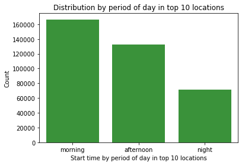

```python
base_color = sns.color_palette()[2]
sns.countplot(data=df_top_10, x='period_of_day', color=base_color)
plt.xlabel('Start time by period of day in top 10 locations')
plt.ylabel('Count')
plt.title('Distribution by period of day in top 10 locations');
```

As previously seen, there was not much difference in the count for Mornings and Afternoons in overall dataframe (All stations). Infact, people used to hire more during the afternoons, although only slightly more.

But, there is a clear difference when considering only the top 10 stations. People ride more or start there rides more during mornings than during any other period of the day in the top 10 stations

## Insight 2

### Day of the week Trend of bike rides

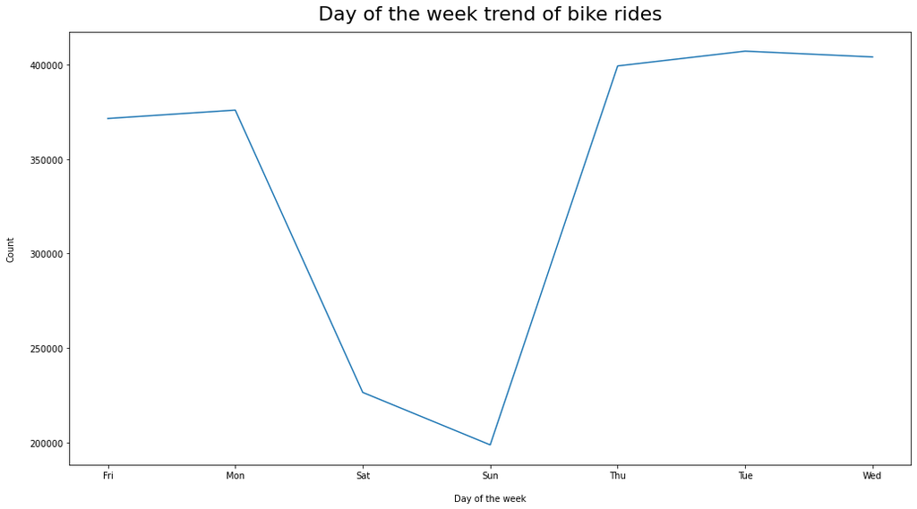

```python
df.groupby('start_weekday_char').agg({'bike_id':'count'}).plot(style='-', legend=False, figsize=(17,9))
plt.title('Day of the week trend of bike rides', fontsize=22, y=1.015)
plt.xlabel('Day of the week', labelpad=16)
plt.ylabel('Count', labelpad=16);
```

On weekends, there is a drastic fall which is unsurprising since people mostly have a holiday from work

### Average ride duration during each day of the week

[figure not shown]

```python
e=df.groupby('start_weekday_char').mean()['duration_sec']
e=e/60
e.plot(kind='bar');
plt.title("Average duration of trip for each day of the week");
plt.xlabel("Day of the week", labelpad=16)
plt.ylabel("Duration in minutes",labelpad=16);
```

# Insight 3

There is a steep decline in the duration of travel for customers from April to May. This can be probably accounted to the fact that it summer and people cannot ride a bike for so long. Interestingly, there is an increase in the average duration from April to May for Subscribers. This makes logical sense since Subscribers as previously seen are huge in number and rent a bike only for shorter durations hence shorter distances. Hence, the impact of weather on such distances can be neglected and hence, the increase.

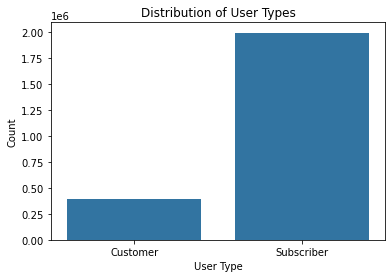

```python
base_color = sns.color_palette()[0]
sns.countplot(data=df, x='user_type', color=base_color)
plt.xlabel('User Type')
plt.ylabel('Count')
plt.title('Distribution of User Types');
```

Approximately 16% users are customers

Approximately 84% users are subscribers

### Duration trend of bike rides per user type

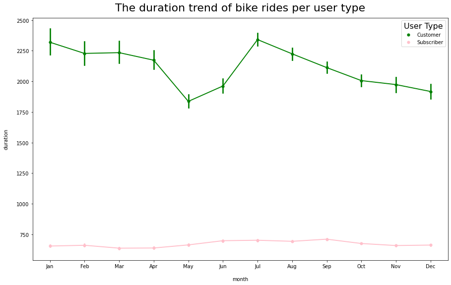

```python
plt.figure(figsize=(15,9))
my_palette = {'Subscriber':'pink', 'Customer':'green'}
ax = sns.pointplot(x='start_month_char', y='duration_sec', hue='user_type', palette=my_palette, scale=.7, data=df)
plt.title('The duration trend of bike rides per user type', fontsize=22, y=1.015)
plt.xlabel('month', labelpad=16)
plt.ylabel('duration', labelpad=16)
leg = ax.legend()
leg.set_title('User Type',prop={'size':16})
ax = plt.gca()
```

The duration for subscribers is way less in comparison to customers.

There is a steep decline in the duration of travel for customers from April to May. This can be probably accounted to the fact that it summer and people cannot ride a bike for so long.

Interestingly, there is an increase in the average duration from April to May for Subscribers. This is logical since Subscribers as previously seen are huge in number and rent a bike only for shorter durations hence shorter distances. Hence, the impact of weather on such distances can be neglected and hence, the increase.